# Bootstrap Confidence Intervals

- Show All Code
- Hide All Code
- View Source

Author

Mauricio Olivares

Published

August 1, 2026

# 1 Bootstrap Confidence Intervals

**Load libraries**

```r
rm(list = ls())
library(ggplot2)
set.seed(42, kind = "L'Ecuyer-CMRG")
```

## 1.1 Overview

We established conditions under which the bootstrap “works,” in the sense that $J_n(t,\hat P_n) - J_n(t,P) \xrightarrow{P} 0$. This chapter uses that result to build confidence intervals directly from the bootstrap distribution, and implements the whole pipeline for the average treatment effect (ATE) under complete randomization.

**NoteWhere this fits**

Everything below is conditional on bootstrap consistency. If you have not yet covered why and when the bootstrap “works,” revisit that chapter first.

## 1.2 From Test Statistics to Confidence Intervals

Suppose we test $H_0 : \theta(P) = 0$ using a statistic $T_n = T_n(W^{(n)})$, with large values of $T_n$ providing evidence against $H_0$ — for instance $T_n = \sqrt n\{\hat\theta_n - \theta(P)\}$. Let $J(t,P)$ denote the asymptotic distribution of $T_n$. At level $\alpha \in (0,1)$ we have considered three rejection rules:

1. **Critical values.** Reject $H_0$ if $T_n > J^{-1}(1-\alpha, P)$.
2. **$p$-values.** Reject $H_0$ if $\hat p < \alpha$.
3. **Confidence intervals.** Reject $H_0$ if $\theta(P)\big|_{H_0} \notin \hat C_n$.

These rules are equivalent. In
$$\mathbb P\!\left(\frac{\hat\theta_n - \theta(P)}{\sqrt{\sigma^2/n}} > c\right) = p,$$
there are three free objects — $\theta(P)$, $c$, $p$ — and fixing any two lets us solve for the third: fix $\theta(P)$ at the null and $c$ at a critical value to get a $p$-value; fix $\theta(P)$ at the null and $p = 1-\alpha$ to get a critical value; fix $c$ and $p = 1-\alpha$ and solve for $\theta(P)$ to get the $(1-\alpha)\times 100\%$ confidence interval.

**ImportantA confidence interval is not a probability statement about $\theta(P)$**

An interval estimator $\hat C_n = [L,U]$ is random because it is built from data, and the requirement is
$$\mathbb P[\theta(P) \in \hat C_n] \ge 1-\alpha,$$
at least asymptotically. Once $\hat\theta_n$ is realized, there is no randomness left: if $\hat C_n = [0,1]$, it is *not* correct to say “there is a 95% chance $\theta(P) \in [0,1]$.” There was a 95% chance $\hat C_n$ would come out that way; this particular realization either contains $\theta(P)$ or it does not. Loosely, $\hat C_n$ gives the range of *likely* values of $\theta(P)$, where “likely” means **confidence**, not probability.

For $T_n = \{\hat\theta_n - \theta(P)\}/\text{s.e.}(\hat\theta_n) \xrightarrow{d} \mathcal N(0,1)$, symmetry of the normal ($z_{1-\alpha/2} = -z_{\alpha/2}$) gives the familiar asymptotic interval
$$\hat C_n(1-\alpha) = \big[\hat\theta_n - z_{1-\alpha/2}\,\text{s.e.}(\hat\theta_n),\; \hat\theta_n + z_{1-\alpha/2}\,\text{s.e.}(\hat\theta_n)\big].$$

## 1.3 The Percentile Bootstrap Confidence Interval

When $J_n(\cdot,P)$ is unknown but the bootstrap works, we replace $P$ by $\hat P_n$ and use bootstrap quantiles directly. With $J_n^{-1}(\tau,P) = \inf\{t : J_n(t,P) \ge \tau\}$, the infeasible interval
$$\hat C_n(1-\alpha) = \big\{\theta(P) : J_n^{-1}(\alpha/2,P) \le T_n \le J_n^{-1}(1-\alpha/2,P)\big\}$$
has the computable bootstrap analogue
$$\hat C_n^B(1-\alpha) = \big\{\theta(P) : J_n^{-1}(\alpha/2,\hat P_n) \le T_n \le J_n^{-1}(1-\alpha/2,\hat P_n)\big\}.$$

**TipTheorem (asymptotic validity)**

Under the conditions that guarantee bootstrap consistency,
$$\mathbb P\big[\theta(P) \in \hat C_n^B(1-\alpha)\big] \to 1-\alpha.$$
This is the **percentile bootstrap confidence interval**.

In practice $J_n(t,\hat P_n)$ is intractable, so we approximate it by Monte Carlo:

1. Draw $(X_{1j}^*,\dots,X_{nj}^*)$ i.i.d. from $\hat P_n$ — resample $(x_1,\dots,x_n)$ with replacement — for $j = 1,\dots,B$.
2. Compute $T_{n,j}^*$ for each resample.
3. Use the empirical quantiles of $(T_{n,1}^*,\dots,T_{n,B}^*)$ to approximate the quantiles of $J_n(\cdot,\hat P_n)$.
4. Form $\hat C_n^B(1-\alpha)$ from these estimated quantiles.

## 1.4 Popular Variants in Practice

If $T_n = \sqrt n(\hat\theta_n - \theta_0) \xrightarrow{d} \mathcal N(0,\sigma^2)$ and $\hat\sigma^2$ is consistent for $\sigma^2$, the **studentized bootstrap** (percentile-$t$) interval is
$$\hat C_n^B(1-\alpha) = \left\{\theta(P) : \hat\theta_n - \frac{J_n^{-1}(1-\alpha/2,\hat P_n)\,\hat\sigma}{\sqrt n} \le \theta(P) \le \hat\theta_n - \frac{J_n^{-1}(\alpha/2,\hat P_n)\,\hat\sigma}{\sqrt n}\right\},$$
note the reversed quantiles relative to the plug-in normal interval
$$\hat C_n(1-\alpha) = \left\{\theta(P): \hat\theta_n - z_{1-\alpha/2}\frac{\hat\sigma}{\sqrt n} \le \theta(P) \le \hat\theta_n + z_{1-\alpha/2}\frac{\hat\sigma}{\sqrt n}\right\}.$$
Two further variants used routinely in practice replace $\hat\sigma$ by a bootstrap estimate of the standard error itself, computed from the bootstrap draws $\theta_{n,1}^*,\dots,\theta_{n,B}^*$ (implicitly treating $\theta(\hat P_n) = \hat\theta_n$).

### 1.4.1 What Some Practitioners Do: Case I

Use the second moment of the bootstrap sampling distribution,
$$\hat s_n^{*2} = \mathbb E_{\hat P_n}\big[n\{\theta_n^* - \theta(\hat P_n)\}^2\big] ,$$
approximated by Monte Carlo as
$$\hat s_{n,B}^{*} = \left\{\frac{1}{B}\sum_{j=1}^B n\big(\theta^*_{n,j} - \hat\theta_n\big)^2\right\}^{1/2},$$
and form the interval $\{\hat\theta_n \pm z_{1-\alpha/2}\,\hat s_{n,B}^*/\sqrt n\}$.

### 1.4.2 What Some Practitioners Do: Case II

Alternatively, use the bootstrap *variance* to estimate $\sigma^2$,
$$\hat\sigma_n^{*2} = \underbrace{\mathbb E_{\hat P_n}\big[n\{\theta_n^*-\theta(\hat P_n)\}^2\big]}_{\equiv\, \hat s_n^{*2}} - \Big(\mathbb E_{\hat P_n}\big[\sqrt n\{\theta_n^* - \hat\theta_n\}\big]\Big)^2 ,$$
approximated by Monte Carlo as
$$\hat\sigma_{n,B}^{*2} = \underbrace{\frac{1}{B}\sum_{j=1}^B n\big(\theta^*_{n,j} - \hat\theta_n\big)^2}_{\equiv\, \hat s_{n,B}^{*2}} - \left(\frac{1}{B}\sum_{j=1}^B \sqrt n\big\{\theta^*_{n,j} - \hat\theta_n\big\}\right)^{2} ,$$
and form the interval $\{\hat\theta_n \pm z_{1-\alpha/2}\,\hat\sigma_{n,B}^*/\sqrt n\}$.

Both cases follow the same three-step Monte Carlo recipe: (1) resample with replacement and compute $\theta_{n,j}^*$; (2) repeat for $j=1,\dots,B$; (3) plug $\hat s_{n,B}^*$ (Case I) or $\hat\sigma_{n,B}^*$ (Case II) into the normal-approximation interval above.

**ImportantWhy this is not a free lunch**

Neither $\hat\sigma_n^{*2}$ (Case II) nor $\hat s_n^{*2}$ (Case I) is consistent for $\sigma^2$ under bootstrap consistency alone:
$$\liminf_{n\to\infty} \hat\sigma_n^{*2} \ge \sigma^2, \qquad \liminf_{n\to\infty} \hat s_n^{*2} \ge \sigma^2, \qquad P\text{-a.s.}$$
Weak convergence of the bootstrap does not imply convergence of its moments; consistency of the bootstrap standard error requires uniform integrability, a strictly stronger condition. Intervals built from Case I or Case II therefore tend to be **conservative**, since $\hat s_n^{*2} \ge \hat\sigma_n^{*2}$ always. The percentile interval from Section 1.3 avoids this issue entirely, since it never estimates $\sigma^2$ as an intermediate step.

## 1.5 Hands-On: Bootstrapping the ATE Confidence Interval

We implement the percentile, Efron, Case I, and Case II constructions for the difference-in-means estimator of the ATE under complete randomization.

### 1.5.1 Simulated Data

**Simulate outcomes under complete randomization**

```r
n <- 2000
treatment <- rbinom(n, 1, 0.5)
error <- rnorm(n, mean = 0, sd = 5)
effect_size <- 3
outcome <- 50 + treatment * effect_size + error

data <- data.frame(treatment = treatment, outcome = outcome)
head(data, 5)
```

```
  treatment  outcome
1         0 50.75962
2         1 53.98284
3         0 48.04542
4         1 53.31707
5         1 42.82422
```

The true effect is `effect_size = 3`; we recover it, and a confidence interval around it, from a sample of $n = 2000$ units.

### 1.5.2 Estimator and Its Variance

**Define the ATE estimator and its variance estimator**

```r
theta_hat <- function(data) {
  mean(data$outcome[data$treatment == 1]) -
    mean(data$outcome[data$treatment == 0])
}

var_theta_hat <- function(data) {
  n1 <- sum(data$treatment == 1)
  n0 <- sum(data$treatment == 0)
  var(data$outcome[data$treatment == 1]) / n1 +
    var(data$outcome[data$treatment == 0]) / n0
}

theta_hat_n <- theta_hat(data)
sigma_hat <- sqrt(var_theta_hat(data))
c(theta_hat_n = theta_hat_n, sigma_hat = sigma_hat)
```

```
theta_hat_n   sigma_hat
  3.2336287   0.2236813
```

$\hat\theta_n$ is the Neyman difference-in-means estimator; $\hat\sigma^2$ is the Neyman variance estimator (sum of within-arm sample variances scaled by arm sizes).

### 1.5.3 The Bootstrap Resampling Algorithm

**Resample with replacement and recompute the statistic**

```r
bootstrap_estimator <- function(data, B = 2000) {
  theta_hat_n <- theta_hat(data)
  n <- nrow(data)
  bootstraps_theta <- matrix(NA, nrow = B, ncol = 3)
  for (i in 1:B) {
    data_star <- data[sample(nrow(data), replace = TRUE), ]
    bootstraps_theta[i, 1] <- theta_hat(data_star)                   # theta_n^*
    bootstraps_theta[i, 2] <- bootstraps_theta[i, 1] - theta_hat_n   # recentered
    bootstraps_theta[i, 3] <- bootstraps_theta[i, 2] /
      sqrt(var_theta_hat(data_star))                                # studentized
  }
  bootstraps_theta
}
```

### 1.5.4 Percentile and Efron Constructions

**percentile / Efron studentized constructions**

```r
bootstrap_ci <- function(bootstraps_theta, n, sigma_hat,
                          type = c("percentile", "efron"),
                          alpha = 0.05) {
  quantile_lower <- quantile(sqrt(n) * bootstraps_theta[, 2], alpha / 2)
  quantile_upper <- quantile(sqrt(n) * bootstraps_theta[, 2], 1 - alpha / 2)

  if (type == "percentile") {
    ci_lower <- theta_hat_n - unname(quantile_upper) * sigma_hat / sqrt(n)
    ci_upper <- theta_hat_n - unname(quantile_lower) * sigma_hat / sqrt(n)
  } else if (type == "efron") {
    ci_lower <- theta_hat_n + unname(quantile_lower) * sigma_hat / sqrt(n)
    ci_upper <- theta_hat_n + unname(quantile_upper) * sigma_hat / sqrt(n)
  }
  c(lower = ci_lower, upper = ci_upper)
}
```

**NoteCase I and Case II were missing from the original script**

The original `bootstrap_ci.r` had a `type1`/`type2` pair (a basic-bootstrap interval and its reflection around $\hat\theta_n$) that do **not** correspond to the Case I / Case II constructions from Section 1.4.1–Section 1.4.2 — those were never actually computed. The function above keeps only the studentized percentile/Efron pair; Case I and Case II are implemented separately below, exactly as in the lecture.

### 1.5.5 Implementing Case I and Case II

**Case I (second moment) and Case II (centered variance) SE constructions**

```r
bootstrap_se_ci <- function(bootstraps_theta, theta_hat_n, n,
                             type = c("case1", "case2"), alpha = 0.05) {
  s_star_nB <- sqrt(mean(n * (bootstraps_theta[, 1] - theta_hat_n)^2))

  if (type == "case1") {
    se <- s_star_nB
  } else if (type == "case2") {
    cross_term      <- mean(sqrt(n) * (bootstraps_theta[, 1] - theta_hat_n))
    sigma_star2_nB  <- s_star_nB^2 - cross_term^2
    se <- sqrt(sigma_star2_nB)
  }
  theta_hat_n + c(lower = -1, upper = 1) * qnorm(1 - alpha / 2) * se / sqrt(n)
}
```

`s_star_nB` is exactly $\hat s_{n,B}^*$ from Section 1.4.1; Case II subtracts the squared bootstrap mean of $\sqrt n(\theta_{n,j}^*-\hat\theta_n)$ before taking the square root, exactly as $\hat\sigma_{n,B}^{*2}$ in Section 1.4.2. Neither case uses `sigma_hat`: both estimate the standard error from the bootstrap draws alone.

### 1.5.6 Computing the Intervals

**Run B = 1000 bootstrap resamples and compare all constructions**

```r
theta_boot <- bootstrap_estimator(data, B = 1000)

ci_percentile <- bootstrap_ci(theta_boot, n, sigma_hat, type = "percentile")
ci_efron      <- bootstrap_ci(theta_boot, n, sigma_hat, type = "efron")
ci_case1      <- bootstrap_se_ci(theta_boot, theta_hat_n, n, type = "case1")
ci_case2      <- bootstrap_se_ci(theta_boot, theta_hat_n, n, type = "case2")
ci_asym       <- c(lower = theta_hat_n - qnorm(0.975) * sigma_hat,
                    upper = theta_hat_n + qnorm(0.975) * sigma_hat)

results_tab <- data.frame(
  Method = c("Asymptotic normal", "Bootstrap percentile", "Efron's percentile",
             "Case I (second moment)", "Case II (centered variance)"),
  Lower  = c(ci_asym[1], ci_percentile[1], ci_efron[1], ci_case1[1], ci_case2[1]),
  Upper  = c(ci_asym[2], ci_percentile[2], ci_efron[2], ci_case1[2], ci_case2[2])
)
knitr::kable(results_tab, digits = 3)
```

95% confidence intervals for the ATE, five constructions.

| Method | Lower | Upper |
| --- | --- | --- |
| Asymptotic normal | 2.795 | 3.672 |
| Bootstrap percentile | 3.137 | 3.326 |
| Efron’s percentile | 3.142 | 3.330 |
| Case I (second moment) | 2.802 | 3.665 |
| Case II (centered variance) | 2.803 | 3.664 |

### 1.5.7 Visualizing the Bootstrap Distribution

**Plot the bootstrap distribution with the percentile CI**

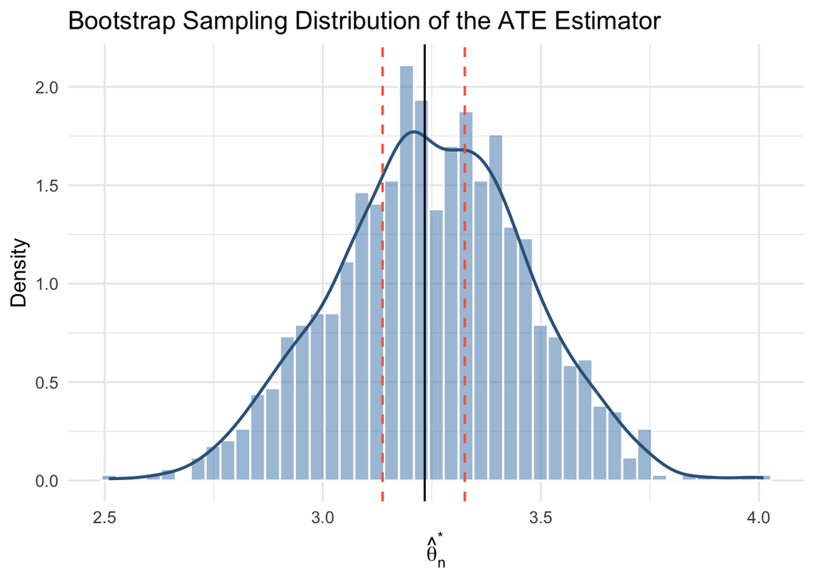

```r
df_boot <- data.frame(theta_star = theta_boot[, 1])

ggplot(df_boot, aes(x = theta_star)) +
  geom_histogram(aes(y = after_stat(density)), bins = 45, fill = "steelblue", alpha = 0.5, colour = "white") +
  geom_density(colour = "steelblue4", linewidth = 0.9) +
  geom_vline(xintercept = c(ci_percentile["lower"], ci_percentile["upper"]),
             colour = "tomato", linetype = "dashed", linewidth = 0.7) +
  geom_vline(xintercept = theta_hat_n, colour = "black", linewidth = 0.6) +
  labs(x = expression(hat(theta)[n]^{"*"}), y = "Density",
       title = "Bootstrap Sampling Distribution of the ATE Estimator") +
  theme_minimal(base_size = 13)
```

### 1.5.8 Checking the “Conservative Bootstrap SE” Claim

**Compare Case I / Case II implied SEs to the analytic SE**

```r
s_star_nB       <- sqrt(mean(n * (theta_boot[, 1] - theta_hat_n)^2))                 # Case I
cross_term      <- mean(sqrt(n) * (theta_boot[, 1] - theta_hat_n))
sigma_star_nB   <- sqrt(s_star_nB^2 - cross_term^2)                                   # Case II
sigma_hat_sqrtn <- sigma_hat * sqrt(n)                                                # analytic

c(analytic_se_sqrtn = sigma_hat_sqrtn, case1_se = s_star_nB, case2_se = sigma_star_nB)
```

```
analytic_se_sqrtn          case1_se          case2_se
        10.003333          9.837981          9.818849
```

## 1.6 Takeaways

- Confidence intervals, critical values, and $p$-values are equivalent rejection rules; fixing two of $(\theta(P), c, p)$ and solving for the third recovers whichever rule you need.
- The percentile bootstrap interval replaces the unknown quantiles $J_n^{-1}(\cdot,P)$ by their bootstrap estimates $J_n^{-1}(\cdot,\hat P_n)$, and is consistent whenever the bootstrap itself is.
- The studentized percentile/Efron pair requires care with quantile reversal.
- Case I and Case II — the bootstrap standard-error plug-ins practitioners often reach for — tend to be conservative, since weak convergence of the bootstrap does not deliver convergence of its second moment. Prefer the percentile construction when in doubt.